# Credit Card Users Churn Prediction

#### Observation

No significant difference observed in months_on_book between churned and existing customers.

#### Attrition_Flag vs Total_Relationship_Count

```
Attrition_Flag               0     1    All
Total_Relationship_Count
All                       8500  1627  10127
3                         1905   400   2305
2                          897   346   1243
1                          677   233    910
5                         1664   227   1891
4                         1687   225   1912
6                         1670   196   1866
------------------------------------------------------------------------------------------------------------------------
```

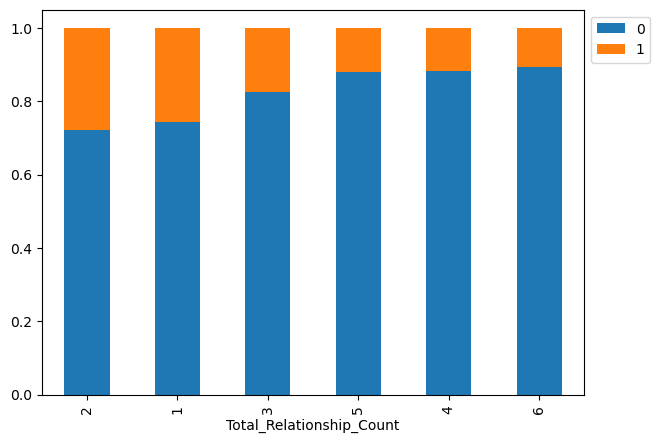

```python
stacked_barplot(data, "Total_Relationship_Count", "Attrition_Flag")
```

#### Observation

Higher no. of products i.e. 3 or more significantly reduces churn risk.

#### Attrition_Flag vs Months_Inactive_12_mon

```
Attrition_Flag             0     1    All
Months_Inactive_12_mon
All                     8500  1627  10127
3                       3020   826   3846
2                       2777   505   3282
4                        305   130    435
1                       2133   100   2233
5                        146    32    178
6                        105    19    124
0                         14    15     29
------------------------------------------------------------------------------------------------------------------------
```

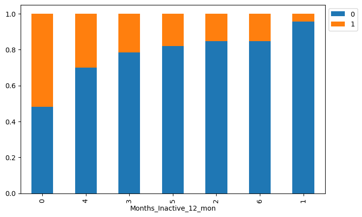

```python
stacked_barplot(data, "Months_Inactive_12_mon", "Attrition_Flag")
```

#### Observations

- Equal no. of customers were retained or churned among those that were fully active last year.
- Customers on either extremes of inactivity i.e. 1-2 months or 5-6 months are less likely to churn.
- Customers with 3-4 months of inactivity are likely to churn.

#### Attrition_Flag vs Contacts_Count_12_mon

```
Attrition_Flag            0     1    All
Contacts_Count_12_mon
All                    8500  1627  10127
3                      2699   681   3380
2                      2824   403   3227
4                      1077   315   1392
1                      1391   108   1499
5                       117    59    176
6                         0    54     54
0                       392     7    399
------------------------------------------------------------------------------------------------------------------------
```

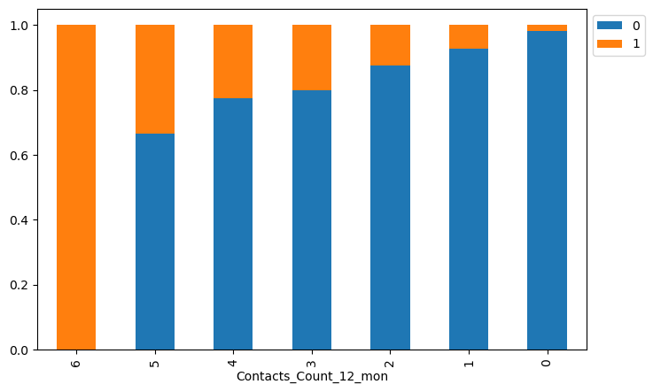

```python
stacked_barplot(data, "Contacts_Count_12_mon", "Attrition_Flag")
```

#### Observation

More contact with the bank equals more churn risk. This can indicate more support calls and dissatisfaction with services.

#### Attrition_Flag vs Credit_Limit

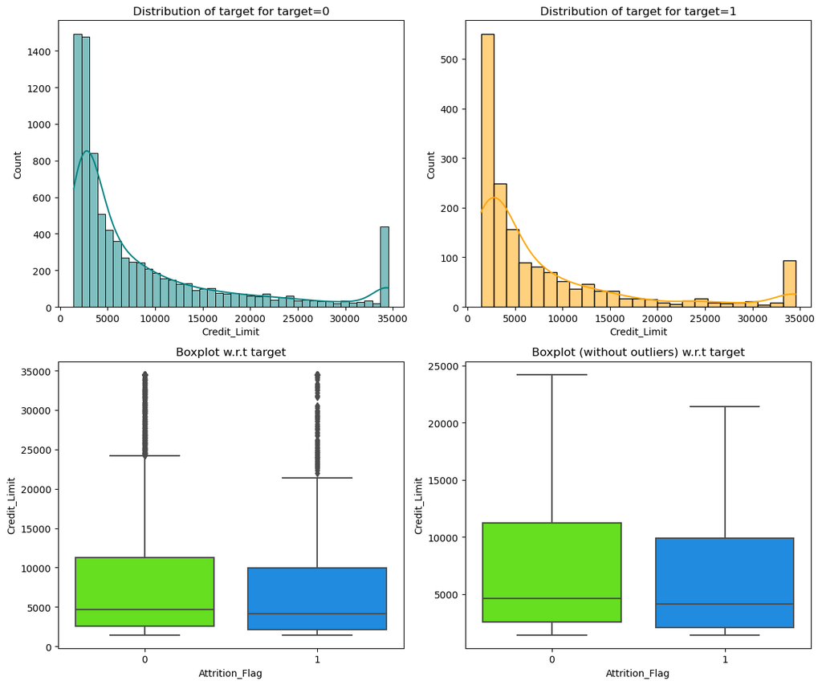

```python
distribution_plot_wrt_target(data, "Credit_Limit", "Attrition_Flag")
```

#### Observations

- Churned customers on average had a lower credit limit.
- However there are many outliers in both cases of target variable.

#### Attrition_Flag vs Total_Revolving_Bal

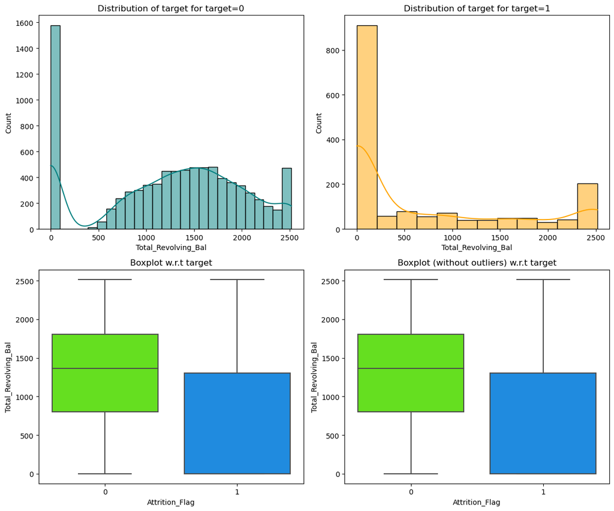

```python
distribution_plot_wrt_target(data, "Total_Revolving_Bal", "Attrition_Flag")
```

#### Observation

Churned customers on average had a much lower, near-0 revolving balance, indicating lacking the need for a credit card.

#### Attrition_Flag vs Avg_Open_To_Buy

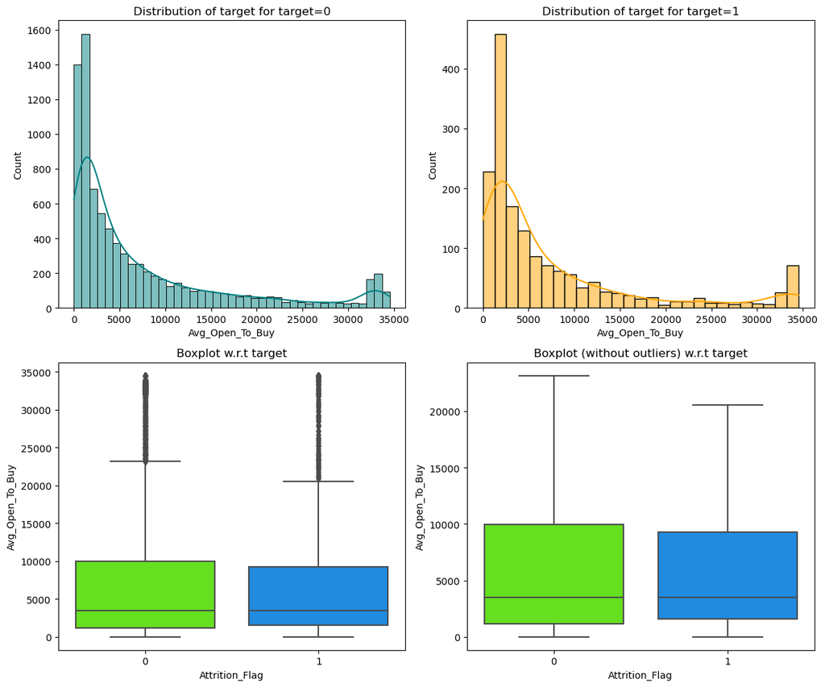

```python
distribution_plot_wrt_target(data, "Avg_Open_To_Buy", "Attrition_Flag")
```

#### Observations

- No significant difference in open_to_buy for existing and churned customers.
- However there are many outliers in both cases of target variable.

#### Attrition_Flag vs Total_Amt_Chng_Q4_Q1

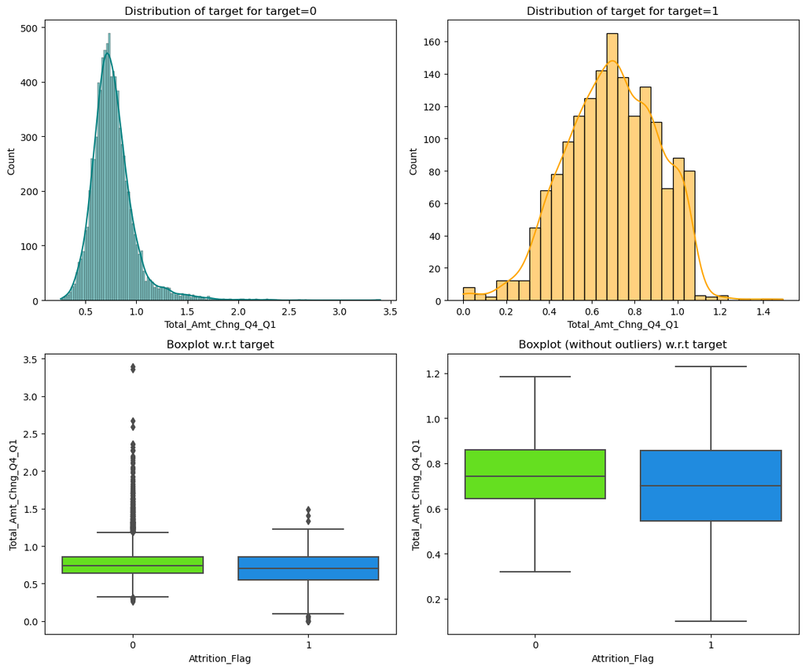

```python
distribution_plot_wrt_target(data, "Total_Amt_Chng_Q4_Q1", "Attrition_Flag")
```

#### Observations

- Churned customers had a lower total amount change in Q4 over Q1.
- However there are many outliers for existing customers.

#### Attrition_Flag vs Total_Trans_Amt

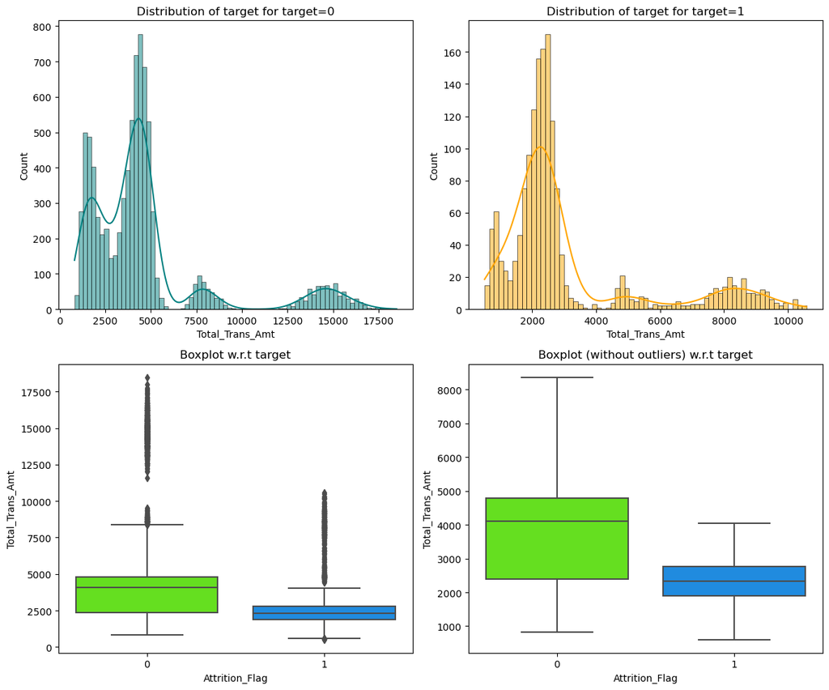

```python
distribution_plot_wrt_target(data, "Total_Trans_Amt", "Attrition_Flag")
```

#### Observations

- Churned customers had a lower total transaction amount.
- However there are many outliers for both churned and existing customers.

#### Attrition_Flag vs Total_Trans_Ct

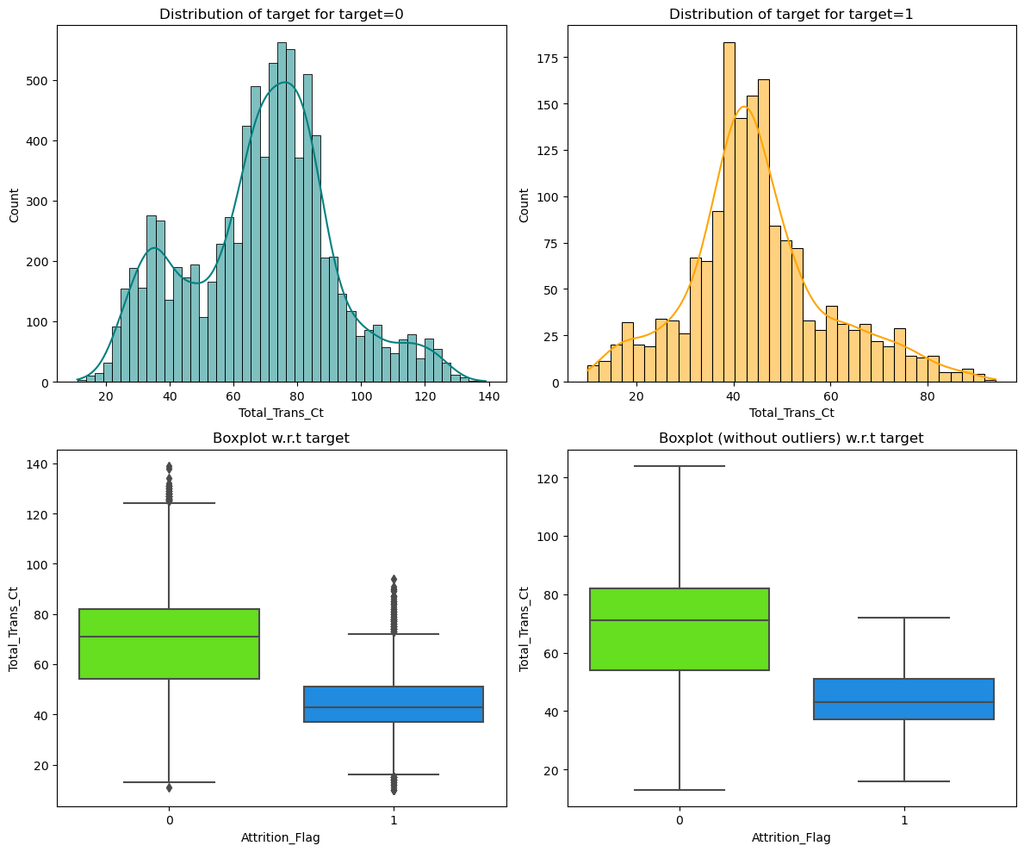

```python
distribution_plot_wrt_target(data, "Total_Trans_Ct", "Attrition_Flag")
```

#### Observations

- Churned customers had a lower total transaction count.
- However there are many outliers for both churned and existing customers.

#### Attrition_Flag vs Total_Ct_Chng_Q4_Q1

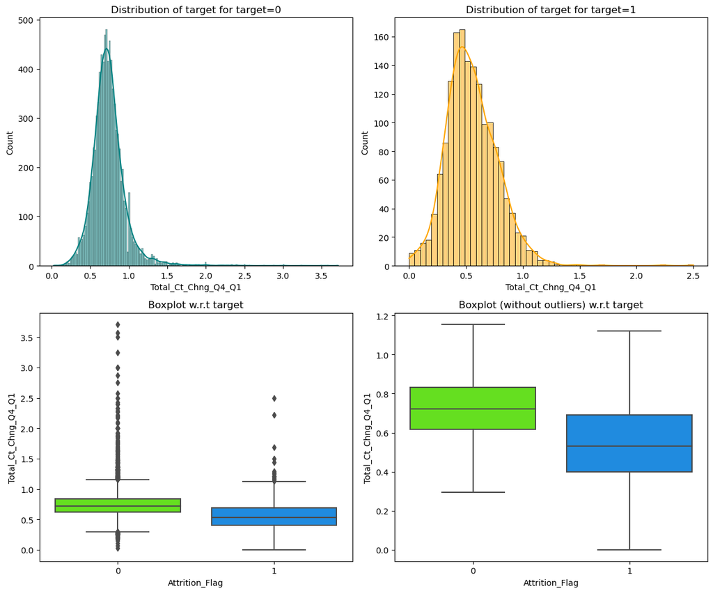

```python
distribution_plot_wrt_target(data, "Total_Ct_Chng_Q4_Q1", "Attrition_Flag")
```

#### Observations

- Churned customers had a lower total change in transaction count in Q4 over Q1.
- However there are many outliers for both churned and existing customers.

#### Attrition_Flag vs Avg_Utilization_Ratio

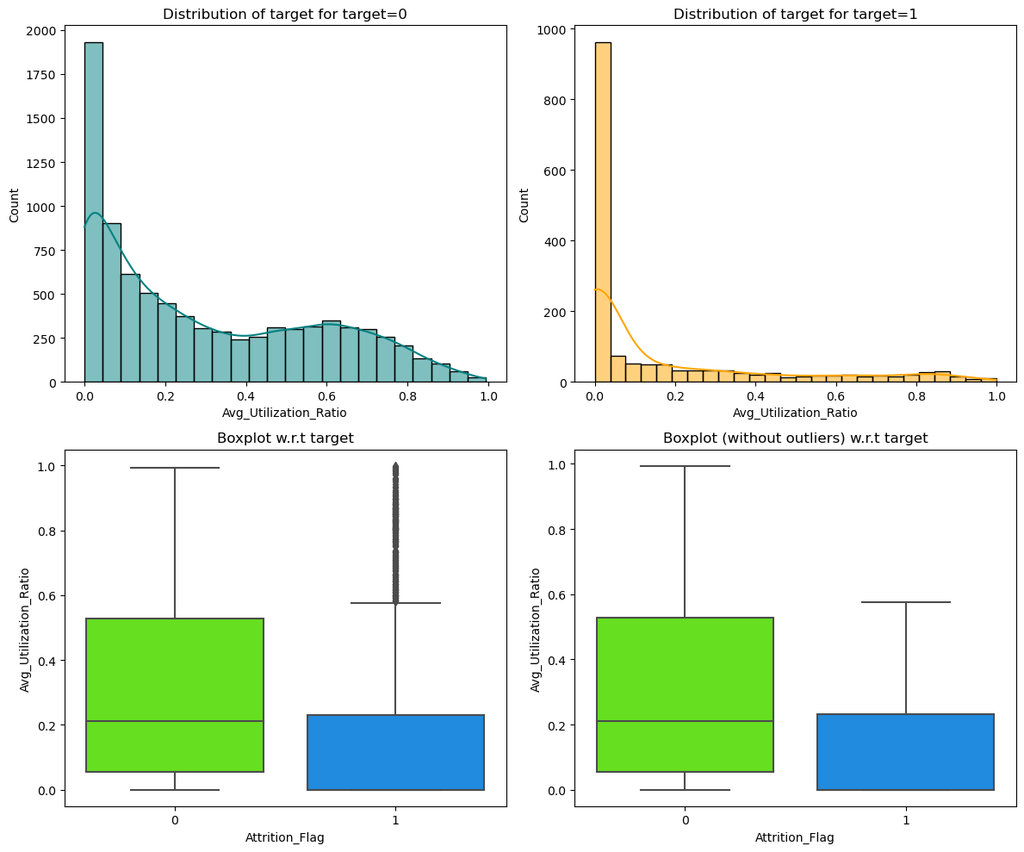

```python
distribution_plot_wrt_target(data, "Avg_Utilization_Ratio", "Attrition_Flag")
```

#### Observations

- Churned customers had a lower average utilization ratio.
- However there are many outliers for both churned customers.

## Data Pre-processing

```python
Q1 = data.quantile(0.25)  # To find the 25th percentile
Q3 = data.quantile(0.75)  # To find the 75th percentile

IQR = Q3 - Q1  # Inter Quantile Range (75th perentile - 25th percentile)

# Finding lower and upper bounds for all values. All values outside these bounds are outliers
lower = (Q1 - 1.5 * IQR)
upper = (Q3 + 1.5 * IQR)
```

```python
((data.select_dtypes(include=["float64", "int64"]) < lower) | (data.select_dtypes(include=["float64", "int64"]) > upper)).sum() / len(data) * 100
```

```
Attrition_Flag             16.066
Customer_Age                0.020
Dependent_count             0.000
Months_on_book              3.812
Total_Relationship_Count    0.000
Months_Inactive_12_mon      3.268
Contacts_Count_12_mon       6.211
Credit_Limit                9.717
Total_Revolving_Bal         0.000
Avg_Open_To_Buy             9.509
Total_Amt_Chng_Q4_Q1        3.910
Total_Trans_Amt             8.848
Total_Trans_Ct              0.020
Total_Ct_Chng_Q4_Q1         3.891
Avg_Utilization_Ratio       0.000
dtype: float64
```

#### Observation

As detailed earlier, we will not do outlier treatment as these records reflect real life scenarios. Some people make considerably more money than others, and some may contact the bank more frequently.

### Missing value imputation

```python
data["Income_Category"].replace("abc", np.nan, inplace=True)
```

```python
data.isna().sum()
```

```
Attrition_Flag                 0
Customer_Age                   0
Gender                         0
Dependent_count                0
Education_Level             1519
Marital_Status               749
Income_Category             1112
Card_Category                  0
Months_on_book                 0
Total_Relationship_Count       0
Months_Inactive_12_mon         0
Contacts_Count_12_mon          0
Credit_Limit                   0
Total_Revolving_Bal            0
Avg_Open_To_Buy                0
Total_Amt_Chng_Q4_Q1           0
Total_Trans_Amt                0
Total_Trans_Ct                 0
Total_Ct_Chng_Q4_Q1            0
Avg_Utilization_Ratio          0
dtype: int64
```

```python
# Creating an instace of the imputer to be used
imputer = SimpleImputer(strategy="most_frequent")
```

```python
# Dividing training data into attributes and target variable

X = data.drop(["Attrition_Flag"], axis=1)
Y = data["Attrition_Flag"]
```

```python
# Splitting data into training, test and validation sets before imputation to avoid data leakage

X_temp, X_test, y_temp, y_test = train_test_split(X, Y, test_size=0.20, random_state=1, stratify=Y)

X_train, X_val, y_train, y_val = train_test_split(X_temp, y_temp, test_size=0.25, random_state=1, stratify=y_temp)

print(X_train.shape, X_val.shape, X_test.shape)
```

```
(6075, 19) (2026, 19) (2026, 19)
```

```python
impute_cols = ["Education_Level", "Marital_Status", "Income_Category"]
```

```python
# Fit and transform the train data
X_train[impute_cols] = imputer.fit_transform(X_train[impute_cols])

# Transform the validation data
X_val[impute_cols] = imputer.fit_transform(X_val[impute_cols])

# Transform the test data
X_test[impute_cols] = imputer.fit_transform(X_test[impute_cols])
```

```python
# Checking that no column has missing values in train or test sets
print(X_train.isna().sum())
print("-" * 30)
print(X_val.isna().sum())
print("-" * 30)
print(X_test.isna().sum())
```

```
Customer_Age                0
Gender                      0
Dependent_count             0
Education_Level             0
Marital_Status              0
Income_Category             0
Card_Category               0
Months_on_book              0
Total_Relationship_Count    0
Months_Inactive_12_mon      0
Contacts_Count_12_mon       0
Credit_Limit                0
Total_Revolving_Bal         0
Avg_Open_To_Buy             0
Total_Amt_Chng_Q4_Q1        0
Total_Trans_Amt             0
Total_Trans_Ct              0
Total_Ct_Chng_Q4_Q1         0
Avg_Utilization_Ratio       0
dtype: int64
------------------------------
Customer_Age                0
Gender                      0
Dependent_count             0
Education_Level             0
Marital_Status              0
Income_Category             0
Card_Category               0
Months_on_book              0
Total_Relationship_Count    0
Months_Inactive_12_mon      0
Contacts_Count_12_mon       0
Credit_Limit                0
Total_Revolving_Bal         0
Avg_Open_To_Buy             0
Total_Amt_Chng_Q4_Q1        0
Total_Trans_Amt             0
Total_Trans_Ct              0
Total_Ct_Chng_Q4_Q1         0
Avg_Utilization_Ratio       0
dtype: int64
------------------------------
Customer_Age                0
Gender                      0
Dependent_count             0
Education_Level             0
Marital_Status              0
Income_Category             0
Card_Category               0
Months_on_book              0
Total_Relationship_Count    0
Months_Inactive_12_mon      0
Contacts_Count_12_mon       0
Credit_Limit                0
Total_Revolving_Bal         0
Avg_Open_To_Buy             0
Total_Amt_Chng_Q4_Q1        0
Total_Trans_Amt             0
Total_Trans_Ct              0
Total_Ct_Chng_Q4_Q1         0
Avg_Utilization_Ratio       0
dtype: int64
```

```python
# Creating dummy variables for each split
X_train = pd.get_dummies(X_train, drop_first=True)
X_val = pd.get_dummies(X_val, drop_first=True)
X_test = pd.get_dummies(X_test, drop_first=True)
print(X_train.shape, X_val.shape, X_test.shape)
```

```
(6075, 29) (2026, 29) (2026, 29)
```

```python
X_train.head()
```

|  | Customer_Age | Dependent_count | Months_on_book | Total_Relationship_Count | Months_Inactive_12_mon | Contacts_Count_12_mon | Credit_Limit | Total_Revolving_Bal | Avg_Open_To_Buy | Total_Amt_Chng_Q4_Q1 | Total_Trans_Amt | Total_Trans_Ct | Total_Ct_Chng_Q4_Q1 | Avg_Utilization_Ratio | Gender_M | Education_Level_Doctorate | Education_Level_Graduate | Education_Level_High School | Education_Level_Post-Graduate | Education_Level_Uneducated | Marital_Status_Married | Marital_Status_Single | Income_Category_$40K - $60K | Income_Category_$60K - $80K | Income_Category_$80K - $120K | Income_Category_Less than $40K | Card_Category_Gold | Card_Category_Platinum | Card_Category_Silver |
| --- | --- | --- | --- | --- | --- | --- | --- | --- | --- | --- | --- | --- | --- | --- | --- | --- | --- | --- | --- | --- | --- | --- | --- | --- | --- | --- | --- | --- | --- |
| 800 | 40 | 2 | 21 | 6 | 4 | 3 | 20056.000 | 1602 | 18454.000 | 0.466 | 1687 | 46 | 0.533 | 0.080 | 1 | 0 | 1 | 0 | 0 | 0 | 0 | 1 | 0 | 0 | 0 | 0 | 0 | 0 | 0 |
| 498 | 44 | 1 | 34 | 6 | 2 | 0 | 2885.000 | 1895 | 990.000 | 0.387 | 1366 | 31 | 0.632 | 0.657 | 1 | 0 | 1 | 0 | 0 | 0 | 1 | 0 | 0 | 0 | 0 | 1 | 0 | 0 | 0 |
| 4356 | 48 | 4 | 36 | 5 | 1 | 2 | 6798.000 | 2517 | 4281.000 | 0.873 | 4327 | 79 | 0.881 | 0.370 | 1 | 0 | 0 | 1 | 0 | 0 | 1 | 0 | 0 | 0 | 1 | 0 | 0 | 0 | 0 |
| 407 | 41 | 2 | 36 | 6 | 2 | 0 | 27000.000 | 0 | 27000.000 | 0.610 | 1209 | 39 | 0.300 | 0.000 | 1 | 0 | 1 | 0 | 0 | 0 | 1 | 0 | 0 | 1 | 0 | 0 | 0 | 0 | 1 |
| 8728 | 46 | 4 | 36 | 2 | 2 | 3 | 15034.000 | 1356 | 13678.000 | 0.754 | 7737 | 84 | 0.750 | 0.090 | 1 | 0 | 0 | 1 | 0 | 0 | 0 | 0 | 1 | 0 | 0 | 0 | 0 | 0 | 1 |

## Model Building

### Model evaluation criterion

The nature of predictions made by the classification model will translate as follows:

- True positives (TP) are customer churns correctly predicted by the model.
- False negatives (FN) are real customer churns where there is no prediction by model.
- False positives (FP) are customer churns predictions where there is no customer churn.

**Which metric to optimize?**

- We need to choose the metric which will ensure that the maximum number of customer churns are predicted correctly by the model.
- We would want Recall to be maximized as greater the Recall, the higher the chances of minimizing false negatives.
- We want to minimize false negatives because if a model predicts that a customer will not churn when there will be a churn, it will mean lost opportunity.

**Let's define a function to output different metrics (including recall) on the train and test set and a function to show confusion matrix so that we do not have to use the same code repetitively while evaluating models.**

```python
# defining a function to compute different metrics to check performance of a classification model built using sklearn
def model_performance_classification_sklearn(model, predictors, target):
    """
    Function to compute different metrics to check classification model performance

    model: classifier
    predictors: independent variables
    target: dependent variable
    """

    # predicting using the independent variables
    pred = model.predict(predictors)

    acc = accuracy_score(target, pred)  # to compute Accuracy
    recall = recall_score(target, pred)  # to compute Recall
    precision = precision_score(target, pred)  # to compute Precision
    f1 = f1_score(target, pred)  # to compute F1-score

    # creating a dataframe of metrics
    df_perf = pd.DataFrame(
        {
            "Accuracy": acc,
            "Recall": recall,
            "Precision": precision,
            "F1": f1

        },
        index=[0],
    )

    return df_perf
```

### Model Building with original data

Sample code for model building with original data

```python
models = []  # Empty list to store all the models

# Appending models into the list
models.append(("DecisionTree", DecisionTreeClassifier(random_state=1, class_weight={0: 15, 1: 85})))
models.append(("Bagging", BaggingClassifier(random_state=1)))
models.append(("Random forest", RandomForestClassifier(random_state=1)))
models.append(("GBM", GradientBoostingClassifier(random_state=1)))
models.append(("Adaboost", AdaBoostClassifier(random_state=1)))
models.append(("Xgboost", XGBClassifier(random_state=1, eval_metric='logloss')))

print("\n" "Training Performance:" "\n")
for name, model in models:
    model.fit(X_train, y_train)
    scores = recall_score(y_train, model.predict(X_train))
    print("{}: {}".format(name, scores))

print("\n" "Validation Performance:" "\n")

for name, model in models:
    model.fit(X_train, y_train)
    scores_val = recall_score(y_val, model.predict(X_val))
    print("{}: {}".format(name, scores_val))
```

```
Training Performance:

DecisionTree: 1.0
Bagging: 0.985655737704918
Random forest: 1.0
GBM: 0.875
Adaboost: 0.826844262295082
Xgboost: 1.0

Validation Performance:

DecisionTree: 0.8067484662576687
Bagging: 0.8128834355828221
Random forest: 0.7975460122699386
GBM: 0.8558282208588958
Adaboost: 0.852760736196319
Xgboost: 0.901840490797546
```

#### Observations

- Random Forest and Decision Tree models are overfitting the data.
- Adaboost and Gradient boosting performed okay, and are good candidates for improvement.
- Between Bagging and Xgboost, while Xgboost overfit the training data it had the best recall on validation. Whereas the Bagging model performed poorly on validation compared to training set compartitively. We can tune the Xgboost model.

### Model Building with Oversampled data

```python
# Synthetic Minority Over Sampling Technique
sm = SMOTE(sampling_strategy=1, k_neighbors=5, random_state=1)
X_train_over, y_train_over = sm.fit_resample(X_train, y_train)
```

```python
print("Before OverSampling, count of label '1': {}".format(sum(y_train == 1)))
print("Before OverSampling, count of label '0': {} \n".format(sum(y_train == 0)))

print("After OverSampling, count of label '1': {}".format(sum(y_train_over == 1)))
print("After OverSampling, count of label '0': {} \n".format(sum(y_train_over == 0)))

print("After OverSampling, the shape of train_X: {}".format(X_train_over.shape))
print("After OverSampling, the shape of train_y: {} \n".format(y_train_over.shape))
```

```
Before OverSampling, count of label '1': 976
Before OverSampling, count of label '0': 5099

After OverSampling, count of label '1': 5099
After OverSampling, count of label '0': 5099

After OverSampling, the shape of train_X: (10198, 29)
After OverSampling, the shape of train_y: (10198,)
```

```python
models = []  # Empty list to store all the models

# Appending models into the list
models.append(("DecisionTree", DecisionTreeClassifier(random_state=1, class_weight={0: 15, 1: 85})))
models.append(("Bagging", BaggingClassifier(random_state=1)))
models.append(("Random forest", RandomForestClassifier(random_state=1)))
models.append(("GBM", GradientBoostingClassifier(random_state=1)))
models.append(("Adaboost", AdaBoostClassifier(random_state=1)))
models.append(("Xgboost", XGBClassifier(random_state=1, eval_metric='logloss')))

print("\n" "Training Performance:" "\n")
for name, model in models:
    model.fit(X_train_over, y_train_over)
    scores = recall_score(y_train, model.predict(X_train))
    print("{}: {}".format(name, scores))

print("\n" "Validation Performance:" "\n")

for name, model in models:
    model.fit(X_train_over, y_train_over)
    scores_val = recall_score(y_val, model.predict(X_val))
    print("{}: {}".format(name, scores_val))
```

```
Training Performance:

DecisionTree: 1.0
Bagging: 0.9938524590163934
Random forest: 1.0
GBM: 0.9334016393442623
Adaboost: 0.8934426229508197
Xgboost: 1.0

Validation Performance:

DecisionTree: 0.7607361963190185
Bagging: 0.8496932515337423
Random forest: 0.8680981595092024
GBM: 0.8926380368098159
Adaboost: 0.901840490797546
Xgboost: 0.911042944785276
```

#### Observations

- The Random Forest and Decision Tree models are still overfitting the data.
- XGBoost overfit the training data but recall on validation set improved and is highest among all models.
- Performance of Bagging, AdaBoost, and GBM improved across both training and validation sets.

### Model Building with Undersampled data

```python
# Random undersampler for under sampling the data
rus = RandomUnderSampler(random_state=1, sampling_strategy=1)
X_train_un, y_train_un = rus.fit_resample(X_train, y_train)
```

```python
print("Before Undersampling, count of label '1': {}".format(sum(y_train == 1)))
print("Before Undersampling, count of label '0': {} \n".format(sum(y_train == 0)))

print("After Undersampling, count of label '1': {}".format(sum(y_train_un == 1)))
print("After Undersampling, count of label '0': {} \n".format(sum(y_train_un == 0)))

print("After Undersampling, the shape of train_X: {}".format(X_train_un.shape))
print("After Undersampling, the shape of train_y: {} \n".format(y_train_un.shape))
```

```
Before Undersampling, count of label '1': 976
Before Undersampling, count of label '0': 5099

After Undersampling, count of label '1': 976
After Undersampling, count of label '0': 976

After Undersampling, the shape of train_X: (1952, 29)
After Undersampling, the shape of train_y: (1952,)
```

```python
models = []  # Empty list to store all the models

# Appending models into the list
models.append(("DecisionTree", DecisionTreeClassifier(random_state=1, class_weight={0: 15, 1: 85})))
models.append(("Bagging", BaggingClassifier(random_state=1)))
models.append(("Random forest", RandomForestClassifier(random_state=1)))
models.append(("GBM", GradientBoostingClassifier(random_state=1)))
models.append(("Adaboost", AdaBoostClassifier(random_state=1)))
models.append(("Xgboost", XGBClassifier(random_state=1, eval_metric='logloss')))

print("\n" "Training Performance:" "\n")
for name, model in models:
    model.fit(X_train_un, y_train_un)
    scores = recall_score(y_train, model.predict(X_train))
    print("{}: {}".format(name, scores))

print("\n" "Validation Performance:" "\n")

for name, model in models:
    model.fit(X_train_un, y_train_un)
    scores_val = recall_score(y_val, model.predict(X_val))
    print("{}: {}".format(name, scores_val))
```

```
Training Performance:

DecisionTree: 1.0
Bagging: 0.9907786885245902
Random forest: 1.0
GBM: 0.9805327868852459
Adaboost: 0.9528688524590164
Xgboost: 1.0

Validation Performance:

DecisionTree: 0.8711656441717791
Bagging: 0.9294478527607362
Random forest: 0.9386503067484663
GBM: 0.9570552147239264
Adaboost: 0.9601226993865031
Xgboost: 0.9693251533742331
```

#### Observations

- The Random Forest and Decision Tree models are still overfitting the data.
- XGBoost overfit the training data but recall on validation set improved again and is still the best among all.
- Performance of Bagging, AdaBoost, and GBM improved across both training and validation sets.

We will select AdaBoost, GBM and XGBoost models to tune further as they seem to give the best recall measures with generalized fits. We will tune Decision Tree model too for comparison.

### HyperparameterTuning

#### Sample Parameter Grids

**Hyperparameter tuning can take a long time to run, so to avoid that time complexity - you can use the following grids, wherever required.**

- For Gradient Boosting:

```
param_grid = {
    "init": [AdaBoostClassifier(random_state=1),DecisionTreeClassifier(random_state=1)],
    "n_estimators": np.arange(75,150,25),
    "learning_rate": [0.1, 0.01, 0.2, 0.05, 1],
    "subsample":[0.5,0.7,1],
    "max_features":[0.5,0.7,1],
}
```

- For Adaboost:

```
param_grid = {
     "n_estimators": np.arange(10, 110, 10),
     "learning_rate": [0.1, 0.01, 0.2, 0.05, 1],
     "base_estimator": [
         DecisionTreeClassifier(max_depth=1, random_state=1),
         DecisionTreeClassifier(max_depth=2, random_state=1),
         DecisionTreeClassifier(max_depth=3, random_state=1),
    ]
}
```

- For Bagging Classifier:

```
param_grid = {
    'max_samples': [0.8,0.9,1],
    'max_features': [0.7,0.8,0.9],
    'n_estimators' : [30,50,70],
}
```

- For Random Forest:

```
param_grid = {
    "n_estimators": [200,250,300],
    "min_samples_leaf": np.arange(1, 4),
    "max_features": [np.arange(0.3, 0.6, 0.1),'sqrt'],
    "max_samples": np.arange(0.4, 0.7, 0.1)
}
```

- For Decision Trees:

```
param_grid = {
    'max_depth': np.arange(2,6),
    'min_samples_leaf': [1, 4, 7],
    'max_leaf_nodes' : [10, 15],
    'min_impurity_decrease': [0.0001,0.001]
}
```

- For XGBoost:

```
param_grid={
   'n_estimators':np.arange(50,300,50),
   'scale_pos_weight':[0,1,2,5,10],
   'learning_rate':[0.01,0.1,0.2,0.05],
   'gamma':[0,1,3,5],
   'subsample':[0.7,0.8,0.9,1]
}
```

#### Sample tuning method for Decision tree with original data

```python
from sklearn import metrics

scorer = metrics.make_scorer(metrics.recall_score)
```

```python
# defining model
Model = DecisionTreeClassifier(random_state=1)

# Parameter grid to pass in RandomSearchCV
param_grid = {'max_depth': np.arange(2,6),
              'min_samples_leaf': [1, 4, 7],
              'max_leaf_nodes' : [10,15],
              'min_impurity_decrease': [0.0001,0.001] }

#Calling RandomizedSearchCV
randomized_cv = RandomizedSearchCV(estimator=Model, param_distributions=param_grid, n_iter=10, n_jobs = -1, scoring=scorer, cv=5, random_state=1)

#Fitting parameters in RandomizedSearchCV
randomized_cv.fit(X_train,y_train)

print("Best parameters are {} with CV score={}:" .format(randomized_cv.best_params_,randomized_cv.best_score_))
```

```
Best parameters are {'min_samples_leaf': 7, 'min_impurity_decrease': 0.0001, 'max_leaf_nodes': 15, 'max_depth': 5} with CV score=0.751941391941392:
```

```python
best_params_dtree_orig = randomized_cv.best_params_
dtree_tuned = DecisionTreeClassifier(**best_params_dtree_orig, random_state=1)
dtree_tuned.fit(X_train, y_train)
```

```
DecisionTreeClassifier(max_depth=5, max_leaf_nodes=15,
                       min_impurity_decrease=0.0001, min_samples_leaf=7,
                       random_state=1)
```

```python
# Checking model's performance on training set
dtree_orig_train = model_performance_classification_sklearn(dtree_tuned, X_train, y_train)
dtree_orig_train
```

|  | Accuracy | Recall | Precision | F1 |
| --- | --- | --- | --- | --- |
| 0 | 0.939 | 0.805 | 0.812 | 0.809 |

```python
# Checking model's performance on validation set
dtree_orig_val = model_performance_classification_sklearn(dtree_tuned, X_val, y_val)
dtree_orig_val
```

|  | Accuracy | Recall | Precision | F1 |
| --- | --- | --- | --- | --- |
| 0 | 0.930 | 0.782 | 0.785 | 0.783 |

#### Sample tuning method for Decision tree with oversampled data

```python
# defining model
Model = DecisionTreeClassifier(random_state=1)

# Parameter grid to pass in RandomSearchCV
param_grid = {'max_depth': np.arange(2,6),
              'min_samples_leaf': [1, 4, 7],
              'max_leaf_nodes' : [10,15],
              'min_impurity_decrease': [0.0001,0.001] }

#Calling RandomizedSearchCV
randomized_cv = RandomizedSearchCV(estimator=Model, param_distributions=param_grid, n_iter=10, n_jobs = -1, scoring=scorer, cv=5, random_state=1)

#Fitting parameters in RandomizedSearchCV
randomized_cv.fit(X_train_over,y_train_over)

print("Best parameters are {} with CV score={}:" .format(randomized_cv.best_params_,randomized_cv.best_score_))
```

```
Best parameters are {'min_samples_leaf': 1, 'min_impurity_decrease': 0.001, 'max_leaf_nodes': 15, 'max_depth': 4} with CV score=0.9111622313302161:
```

```python
#fit new tuned Decision Tree model with oversampled data
best_params_dtree_over = randomized_cv.best_params_
dtree_tuned_over = DecisionTreeClassifier(**best_params_dtree_over, random_state=1)
dtree_tuned_over.fit(X_train_over, y_train_over)
```

```
DecisionTreeClassifier(max_depth=4, max_leaf_nodes=15,
                       min_impurity_decrease=0.001, random_state=1)
```

```python
# Checking model's performance on training set
dtree_over_train = model_performance_classification_sklearn(dtree_tuned_over, X_train_over, y_train_over)
dtree_over_train
```

|  | Accuracy | Recall | Precision | F1 |
| --- | --- | --- | --- | --- |
| 0 | 0.918 | 0.909 | 0.925 | 0.917 |

```python
# Checking model's performance on validation set
dtree_over_val = model_performance_classification_sklearn(dtree_tuned_over, X_val, y_val)
dtree_over_val
```

|  | Accuracy | Recall | Precision | F1 |
| --- | --- | --- | --- | --- |
| 0 | 0.914 | 0.862 | 0.685 | 0.764 |

#### Sample tuning method for Decision tree with undersampled data

```python
# defining model
Model = DecisionTreeClassifier(random_state=1)

# Parameter grid to pass in RandomSearchCV
param_grid = {'max_depth': np.arange(2,20),
              'min_samples_leaf': [1, 2, 5, 7],
              'max_leaf_nodes' : [5, 10,15],
              'min_impurity_decrease': [0.0001,0.001] }

#Calling RandomizedSearchCV
randomized_cv = RandomizedSearchCV(estimator=Model, param_distributions=param_grid, n_iter=10, n_jobs = -1, scoring=scorer, cv=5, random_state=1)

#Fitting parameters in RandomizedSearchCV
randomized_cv.fit(X_train_un,y_train_un)

print("Best parameters are {} with CV score={}:" .format(randomized_cv.best_params_,randomized_cv.best_score_))
```

```
Best parameters are {'min_samples_leaf': 1, 'min_impurity_decrease': 0.001, 'max_leaf_nodes': 5, 'max_depth': 14} with CV score=0.9539141810570383:
```

```python
#fit new tuned Decision Tree model with original data
best_params_dtree_under = randomized_cv.best_params_
dtree_tuned_under = DecisionTreeClassifier(**best_params_dtree_under, random_state=1)
dtree_tuned_under.fit(X_train_un, y_train_un)
```

```
DecisionTreeClassifier(max_depth=14, max_leaf_nodes=5,
                       min_impurity_decrease=0.001, random_state=1)
```

```python
# Checking model's performance on training set
dtree_under_train = model_performance_classification_sklearn(dtree_tuned_under, X_train_un, y_train_un)
dtree_under_train
```

|  | Accuracy | Recall | Precision | F1 |
| --- | --- | --- | --- | --- |
| 0 | 0.831 | 0.969 | 0.760 | 0.852 |

```python
# Checking model's performance on validation set
dtree_under_val = model_performance_classification_sklearn(dtree_tuned_under, X_val, y_val)
dtree_under_val
```

|  | Accuracy | Recall | Precision | F1 |
| --- | --- | --- | --- | --- |
| 0 | 0.735 | 0.966 | 0.375 | 0.540 |

#### Tuning GBM model with original data

```python
%%time

#defining model
Model = GradientBoostingClassifier(random_state=1)

#Parameter grid to pass in RandomSearchCV
param_grid = {
    "init": [AdaBoostClassifier(random_state=1),DecisionTreeClassifier(random_state=1)],
    "n_estimators": np.arange(75,150,25),
    "learning_rate": [0.1, 0.01, 0.2, 0.05, 1],
    "subsample":[0.5,0.7,1],
    "max_features":[0.5,0.7,1],
}

# Type of scoring used to compare parameter combinations
scorer = metrics.make_scorer(metrics.recall_score)

#Calling RandomizedSearchCV
randomized_cv = RandomizedSearchCV(estimator=Model, param_distributions=param_grid, n_iter=50, scoring=scorer, cv=5, random_state=1, n_jobs = -1)

#Fitting parameters in RandomizedSearchCV
randomized_cv.fit(X_train, y_train)

print("Best parameters are {} with CV score={}:" .format(randomized_cv.best_params_,randomized_cv.best_score_))
```

```
Best parameters are {'subsample': 0.7, 'n_estimators': 125, 'max_features': 0.7, 'learning_rate': 0.2, 'init': AdaBoostClassifier(random_state=1)} with CV score=0.8596180010465725:
CPU times: total: 4.42 s
Wall time: 2min
```

```python
#fit tuned GBM model with original data
best_params_gbm_orig = randomized_cv.best_params_
gbm_orig_tuned = GradientBoostingClassifier(**best_params_gbm_orig, random_state=1)
gbm_orig_tuned.fit(X_train, y_train)
```

```
GradientBoostingClassifier(init=AdaBoostClassifier(random_state=1),
                           learning_rate=0.2, max_features=0.7,
                           n_estimators=125, random_state=1, subsample=0.7)
```

```python
# Checking model's performance on training set
gbm_orig_train = model_performance_classification_sklearn(gbm_orig_tuned, X_train, y_train)
gbm_orig_train
```

|  | Accuracy | Recall | Precision | F1 |
| --- | --- | --- | --- | --- |
| 0 | 0.988 | 0.946 | 0.980 | 0.962 |

```python
# Checking model's performance on validation set
gbm_orig_val = model_performance_classification_sklearn(gbm_orig_tuned, X_val, y_val)
gbm_orig_val
```

|  | Accuracy | Recall | Precision | F1 |
| --- | --- | --- | --- | --- |
| 0 | 0.969 | 0.880 | 0.926 | 0.903 |

#### Tuning GBM model with oversampled data

```python
%%time

#defining model
Model = GradientBoostingClassifier(random_state=1)

#Parameter grid to pass in RandomSearchCV
param_grid = {
    "init": [AdaBoostClassifier(random_state=1),DecisionTreeClassifier(random_state=1)],
    "n_estimators": np.arange(75,150,25),
    "learning_rate": [0.1, 0.01, 0.2, 0.05, 1],
    "subsample":[0.5,0.7,1],
    "max_features":[0.5,0.7,1],
}

# Type of scoring used to compare parameter combinations
scorer = metrics.make_scorer(metrics.recall_score)

#Calling RandomizedSearchCV
randomized_cv = RandomizedSearchCV(estimator=Model, param_distributions=param_grid, n_iter=50, scoring=scorer, cv=5, random_state=1, n_jobs = -1)

#Fitting parameters in RandomizedSearchCV
randomized_cv.fit(X_train_over, y_train_over)

print("Best parameters are {} with CV score={}:" .format(randomized_cv.best_params_,randomized_cv.best_score_))
```

```
Best parameters are {'subsample': 0.7, 'n_estimators': 125, 'max_features': 0.7, 'learning_rate': 0.2, 'init': AdaBoostClassifier(random_state=1)} with CV score=0.9474505955473456:
CPU times: total: 7.42 s
Wall time: 3min 36s
```

```python
#fit tuned GBM model with oversampled data
best_params_gbm_over = randomized_cv.best_params_
gbm_over_tuned = GradientBoostingClassifier(**best_params_gbm_over, random_state=1)
gbm_over_tuned.fit(X_train_over, y_train_over)
```

```
GradientBoostingClassifier(init=AdaBoostClassifier(random_state=1),
                           learning_rate=0.2, max_features=0.7,
                           n_estimators=125, random_state=1, subsample=0.7)
```

```python
# Checking model's performance on training set
gbm_over_train = model_performance_classification_sklearn(gbm_over_tuned, X_train_over, y_train_over)
gbm_over_train
```

|  | Accuracy | Recall | Precision | F1 |
| --- | --- | --- | --- | --- |
| 0 | 0.989 | 0.990 | 0.987 | 0.989 |

```python
# Checking model's performance on validation set
gbm_over_val = model_performance_classification_sklearn(gbm_over_tuned, X_val, y_val)
gbm_over_val
```

|  | Accuracy | Recall | Precision | F1 |
| --- | --- | --- | --- | --- |
| 0 | 0.966 | 0.914 | 0.882 | 0.898 |

#### Tuning GBM model with undersampled data

```python
%%time

#defining model
Model = GradientBoostingClassifier(random_state=1)

#Parameter grid to pass in RandomSearchCV
param_grid = {
    "init": [AdaBoostClassifier(random_state=1),DecisionTreeClassifier(random_state=1)],
    "n_estimators": np.arange(75,150,25),
    "learning_rate": [0.1, 0.01, 0.2, 0.05, 1],
    "subsample":[0.5,0.7,1],
    "max_features":[0.5,0.7,1],
}

# Type of scoring used to compare parameter combinations
scorer = metrics.make_scorer(metrics.recall_score)

#Calling RandomizedSearchCV
randomized_cv = RandomizedSearchCV(estimator=Model, param_distributions=param_grid, n_iter=50, scoring=scorer, cv=5, random_state=1, n_jobs = -1)

#Fitting parameters in RandomizedSearchCV
randomized_cv.fit(X_train_un, y_train_un)

print("Best parameters are {} with CV score={}:" .format(randomized_cv.best_params_,randomized_cv.best_score_))
```

```
Best parameters are {'subsample': 0.7, 'n_estimators': 125, 'max_features': 0.7, 'learning_rate': 0.2, 'init': AdaBoostClassifier(random_state=1)} with CV score=0.9559340659340659:
CPU times: total: 2.73 s
Wall time: 57.8 s
```

```python
#fit tuned GBM model with oversampled data
best_params_gbm_under = randomized_cv.best_params_
gbm_under_tuned = GradientBoostingClassifier(**best_params_gbm_under, random_state=1)
gbm_under_tuned.fit(X_train_un, y_train_un)
```

```
GradientBoostingClassifier(init=AdaBoostClassifier(random_state=1),
                           learning_rate=0.2, max_features=0.7,
                           n_estimators=125, random_state=1, subsample=0.7)
```

```python
# Checking model's performance on training set
gbm_under_train = model_performance_classification_sklearn(gbm_over_tuned, X_train_un, y_train_un)
gbm_under_train
```

|  | Accuracy | Recall | Precision | F1 |
| --- | --- | --- | --- | --- |
| 0 | 0.972 | 0.959 | 0.985 | 0.972 |

```python
# Checking model's performance on validation set
gbm_under_val = model_performance_classification_sklearn(gbm_under_tuned, X_val, y_val)
gbm_under_val
```

|  | Accuracy | Recall | Precision | F1 |
| --- | --- | --- | --- | --- |
| 0 | 0.945 | 0.957 | 0.763 | 0.849 |

#### Tuning ADABoost model with original data

```python
%%time

# defining model
Model = AdaBoostClassifier(random_state=1)

# Parameter grid to pass in RandomSearchCV
param_grid = {
    "n_estimators": np.arange(10, 110, 10),
    "learning_rate": [0.1, 0.01, 0.2, 0.05, 1],
    "base_estimator": [
        DecisionTreeClassifier(max_depth=1, random_state=1),
        DecisionTreeClassifier(max_depth=2, random_state=1),
        DecisionTreeClassifier(max_depth=3, random_state=1),
    ],
}

# Type of scoring used to compare parameter combinations
scorer = metrics.make_scorer(metrics.recall_score)

#Calling RandomizedSearchCV
randomized_cv = RandomizedSearchCV(estimator=Model, param_distributions=param_grid, n_jobs = -1, n_iter=50, scoring=scorer, cv=5, random_state=1)

#Fitting parameters in RandomizedSearchCV
randomized_cv.fit(X_train, y_train)

print("Best parameters are {} with CV score={}:" .format(randomized_cv.best_params_,randomized_cv.best_score_))
```

```
Best parameters are {'n_estimators': 90, 'learning_rate': 1, 'base_estimator': DecisionTreeClassifier(max_depth=2, random_state=1)} with CV score=0.8637205651491365:
CPU times: total: 3.91 s
Wall time: 2min 12s
```

```python
#fit tuned GBM model with original data
best_params_ada_orig = randomized_cv.best_params_
ada_orig_tuned = AdaBoostClassifier(**best_params_ada_orig, random_state=1)
ada_orig_tuned.fit(X_train, y_train)
```

```
AdaBoostClassifier(base_estimator=DecisionTreeClassifier(max_depth=2,
                                                         random_state=1),
                   learning_rate=1, n_estimators=90, random_state=1)
```

```python
# Checking model's performance on training set
ada_orig_train = model_performance_classification_sklearn(ada_orig_tuned, X_train, y_train)
ada_orig_train
```

|  | Accuracy | Recall | Precision | F1 |
| --- | --- | --- | --- | --- |
| 0 | 0.995 | 0.980 | 0.990 | 0.985 |

```python
# Checking model's performance on validation set
ada_orig_val = model_performance_classification_sklearn(ada_orig_tuned, X_val, y_val)
ada_orig_val
```

|  | Accuracy | Recall | Precision | F1 |
| --- | --- | --- | --- | --- |
| 0 | 0.967 | 0.868 | 0.922 | 0.894 |

#### Tuning ADABoost model with oversampled data

```python
%%time

# defining model
Model = AdaBoostClassifier(random_state=1)

# Parameter grid to pass in RandomSearchCV
param_grid = {
    "n_estimators": np.arange(10, 110, 10),
    "learning_rate": [0.1, 0.01, 0.2, 0.05, 1],
    "base_estimator": [
        DecisionTreeClassifier(max_depth=1, random_state=1),
        DecisionTreeClassifier(max_depth=2, random_state=1),
        DecisionTreeClassifier(max_depth=3, random_state=1),
    ],
}

# Type of scoring used to compare parameter combinations
scorer = metrics.make_scorer(metrics.recall_score)

#Calling RandomizedSearchCV
randomized_cv = RandomizedSearchCV(estimator=Model, param_distributions=param_grid, n_jobs = -1, n_iter=50, scoring=scorer, cv=5, random_state=1)

#Fitting parameters in RandomizedSearchCV
randomized_cv.fit(X_train_over, y_train_over)

print("Best parameters are {} with CV score={}:" .format(randomized_cv.best_params_,randomized_cv.best_score_))
```

```
Best parameters are {'n_estimators': 90, 'learning_rate': 0.1, 'base_estimator': DecisionTreeClassifier(max_depth=3, random_state=1)} with CV score=0.9490188381535146:
CPU times: total: 7.17 s
Wall time: 3min 32s
```

```python
#fit tuned ADA model with original data
best_params_ada_over = randomized_cv.best_params_
ada_over_tuned = AdaBoostClassifier(**best_params_ada_over, random_state=1)
ada_over_tuned.fit(X_train_over, y_train_over)
```

```
AdaBoostClassifier(base_estimator=DecisionTreeClassifier(max_depth=3,
                                                         random_state=1),
                   learning_rate=0.1, n_estimators=90, random_state=1)
```

```python
# Checking model's performance on training set
ada_over_train = model_performance_classification_sklearn(ada_over_tuned, X_train_over, y_train_over)
ada_over_train
```

|  | Accuracy | Recall | Precision | F1 |
| --- | --- | --- | --- | --- |
| 0 | 0.983 | 0.985 | 0.981 | 0.983 |

```python
# Checking model's performance on validation set
ada_over_val = model_performance_classification_sklearn(ada_over_tuned, X_val, y_val)
ada_over_val
```

|  | Accuracy | Recall | Precision | F1 |
| --- | --- | --- | --- | --- |
| 0 | 0.960 | 0.905 | 0.855 | 0.879 |

#### Tuning ADABoost model with undersampled data

```python
%%time

# defining model
Model = AdaBoostClassifier(random_state=1)

# Parameter grid to pass in RandomSearchCV
param_grid = {
    "n_estimators": np.arange(10, 110, 10),
    "learning_rate": [0.1, 0.01, 0.2, 0.05, 1],
    "base_estimator": [
        DecisionTreeClassifier(max_depth=1, random_state=1),
        DecisionTreeClassifier(max_depth=2, random_state=1),
        DecisionTreeClassifier(max_depth=3, random_state=1),
    ],
}

# Type of scoring used to compare parameter combinations
scorer = metrics.make_scorer(metrics.recall_score)

#Calling RandomizedSearchCV
randomized_cv = RandomizedSearchCV(estimator=Model, param_distributions=param_grid, n_jobs = -1, n_iter=50, scoring=scorer, cv=5, random_state=1)

#Fitting parameters in RandomizedSearchCV
randomized_cv.fit(X_train_un, y_train_un)

print("Best parameters are {} with CV score={}:" .format(randomized_cv.best_params_,randomized_cv.best_score_))
```

```
Best parameters are {'n_estimators': 90, 'learning_rate': 0.2, 'base_estimator': DecisionTreeClassifier(max_depth=3, random_state=1)} with CV score=0.949811616954474:
CPU times: total: 1.73 s
Wall time: 53 s
```

```python
#fit tuned ADA model with original data
best_params_ada_under = randomized_cv.best_params_
ada_under_tuned = AdaBoostClassifier(**best_params_ada_under, random_state=1)
ada_under_tuned.fit(X_train_un, y_train_un)
```

```
AdaBoostClassifier(base_estimator=DecisionTreeClassifier(max_depth=3,
                                                         random_state=1),
                   learning_rate=0.2, n_estimators=90, random_state=1)
```

```python
# Checking model's performance on training set
ada_under_train = model_performance_classification_sklearn(ada_under_tuned, X_train_un, y_train_un)
ada_under_train
```

|  | Accuracy | Recall | Precision | F1 |
| --- | --- | --- | --- | --- |
| 0 | 1.000 | 1.000 | 1.000 | 1.000 |

```python
# Checking model's performance on validation set
ada_under_val = model_performance_classification_sklearn(ada_under_tuned, X_val, y_val)
ada_under_val
```

|  | Accuracy | Recall | Precision | F1 |
| --- | --- | --- | --- | --- |
| 0 | 0.935 | 0.963 | 0.725 | 0.827 |

#### Tuning XGBoost model with original data

```python
%%time

# defining model
Model = XGBClassifier(random_state=1,eval_metric='logloss')

#Parameter grid to pass in RandomSearchCV
param_grid={'n_estimators':np.arange(50,300,50),'scale_pos_weight':[0,1,2,5,10],
            'learning_rate':[0.01,0.1,0.2,0.05], 'gamma':[0,1,3,5],
            'subsample':[0.7,0.8,0.9,1]
           }
from sklearn import metrics

# Type of scoring used to compare parameter combinations
scorer = metrics.make_scorer(metrics.recall_score)

#Calling RandomizedSearchCV
randomized_cv = RandomizedSearchCV(estimator=Model, param_distributions=param_grid, n_iter=50, n_jobs = -1, scoring=scorer, cv=5, random_state=1)

#Fitting parameters in RandomizedSearchCV
randomized_cv.fit(X_train,y_train)

print("Best parameters are {} with CV score={}:" .format(randomized_cv.best_params_,randomized_cv.best_score_))
```

```
Best parameters are {'subsample': 0.9, 'scale_pos_weight': 10, 'n_estimators': 200, 'learning_rate': 0.01, 'gamma': 1} with CV score=0.941585557299843:
CPU times: total: 6.45 s
Wall time: 48 s
```

```python
#fit new tuned XGBoost model with original data
best_params_xgb_orig = randomized_cv.best_params_
xgb_orig_tuned = XGBClassifier(**best_params_xgb_orig, random_state=1)
xgb_orig_tuned.fit(X_train, y_train)
```

```
XGBClassifier(base_score=None, booster=None, callbacks=None,
              colsample_bylevel=None, colsample_bynode=None,
              colsample_bytree=None, device=None, early_stopping_rounds=None,
              enable_categorical=False, eval_metric=None, feature_types=None,
              gamma=1, grow_policy=None, importance_type=None,
              interaction_constraints=None, learning_rate=0.01, max_bin=None,
              max_cat_threshold=None, max_cat_to_onehot=None,
              max_delta_step=None, max_depth=None, max_leaves=None,
              min_child_weight=None, missing=nan, monotone_constraints=None,
              multi_strategy=None, n_estimators=200, n_jobs=None,
              num_parallel_tree=None, random_state=1, ...)
```

```python
# Checking model's performance on training set
xgb_orig_train = model_performance_classification_sklearn(xgb_orig_tuned, X_train, y_train)
xgb_orig_train
```

|  | Accuracy | Recall | Precision | F1 |
| --- | --- | --- | --- | --- |
| 0 | 0.941 | 1.000 | 0.731 | 0.845 |

```python
# Checking model's performance on validation set
xgb_orig_val = model_performance_classification_sklearn(xgb_orig_tuned, X_val, y_val)
xgb_orig_val
```

|  | Accuracy | Recall | Precision | F1 |
| --- | --- | --- | --- | --- |
| 0 | 0.927 | 0.957 | 0.700 | 0.808 |

#### Tuning XGBoost model with oversampled data

```python
%%time

# defining model
Model = XGBClassifier(random_state=1,eval_metric='logloss')

#Parameter grid to pass in RandomSearchCV
param_grid={'n_estimators':np.arange(50,300,50),'scale_pos_weight':[0,1,2,5,10],
            'learning_rate':[0.01,0.1,0.2,0.05], 'gamma':[0,1,3,5],
            'subsample':[0.7,0.8,0.9,1]
           }
from sklearn import metrics

# Type of scoring used to compare parameter combinations
scorer = metrics.make_scorer(metrics.recall_score)

#Calling RandomizedSearchCV
randomized_cv = RandomizedSearchCV(estimator=Model, param_distributions=param_grid, n_iter=50, n_jobs = -1, scoring=scorer, cv=5, random_state=1)

#Fitting parameters in RandomizedSearchCV
randomized_cv.fit(X_train_over,y_train_over)

print("Best parameters are {} with CV score={}:" .format(randomized_cv.best_params_,randomized_cv.best_score_))
```

```
Best parameters are {'subsample': 0.9, 'scale_pos_weight': 10, 'n_estimators': 200, 'learning_rate': 0.01, 'gamma': 1} with CV score=0.9933333333333334:
CPU times: total: 9.89 s
Wall time: 1min 2s
```

```python
#fit new tuned XGBoost model with oversampled data
best_params_xgb_over = randomized_cv.best_params_
xgb_over_tuned = XGBClassifier(**best_params_xgb_over, random_state=1)
xgb_over_tuned.fit(X_train_over, y_train_over)
```

```
XGBClassifier(base_score=None, booster=None, callbacks=None,
              colsample_bylevel=None, colsample_bynode=None,
              colsample_bytree=None, device=None, early_stopping_rounds=None,
              enable_categorical=False, eval_metric=None, feature_types=None,
              gamma=1, grow_policy=None, importance_type=None,
              interaction_constraints=None, learning_rate=0.01, max_bin=None,
              max_cat_threshold=None, max_cat_to_onehot=None,
              max_delta_step=None, max_depth=None, max_leaves=None,
              min_child_weight=None, missing=nan, monotone_constraints=None,
              multi_strategy=None, n_estimators=200, n_jobs=None,
              num_parallel_tree=None, random_state=1, ...)
```

```python
# Checking model's performance on training set
xgb_over_train = model_performance_classification_sklearn(xgb_over_tuned, X_train_over, y_train_over)
xgb_over_train
```

|  | Accuracy | Recall | Precision | F1 |
| --- | --- | --- | --- | --- |
| 0 | 0.921 | 1.000 | 0.864 | 0.927 |

```python
# Checking model's performance on validation set
xgb_over_val = model_performance_classification_sklearn(xgb_over_tuned, X_val, y_val)
xgb_over_val
```

|  | Accuracy | Recall | Precision | F1 |
| --- | --- | --- | --- | --- |
| 0 | 0.861 | 0.979 | 0.538 | 0.694 |

#### Tuning XGBoost model with undersampled data

```python
%%time

# defining model
Model = XGBClassifier(random_state=1,eval_metric='logloss')

#Parameter grid to pass in RandomSearchCV
param_grid={'n_estimators':np.arange(50,300,50),'scale_pos_weight':[0,1,2,5,10],
            'learning_rate':[0.01,0.1,0.2,0.05], 'gamma':[0,1,3,5],
            'subsample':[0.7,0.8,0.9,1]
           }
from sklearn import metrics

# Type of scoring used to compare parameter combinations
scorer = metrics.make_scorer(metrics.recall_score)

#Calling RandomizedSearchCV
randomized_cv = RandomizedSearchCV(estimator=Model, param_distributions=param_grid, n_iter=50, n_jobs = -1, scoring=scorer, cv=5, random_state=1)

#Fitting parameters in RandomizedSearchCV
randomized_cv.fit(X_train_un,y_train_un)

print("Best parameters are {} with CV score={}:" .format(randomized_cv.best_params_,randomized_cv.best_score_))
```

```
Best parameters are {'subsample': 1, 'scale_pos_weight': 10, 'n_estimators': 50, 'learning_rate': 0.05, 'gamma': 5} with CV score=0.987723704866562:
CPU times: total: 2.39 s
Wall time: 22.3 s
```

```python
#fit new tuned XGBoost model with oversampled data
best_params_xgb_under = randomized_cv.best_params_
xgb_under_tuned = XGBClassifier(**best_params_xgb_under, random_state=1)
xgb_under_tuned.fit(X_train_un, y_train_un)
```

```
XGBClassifier(base_score=None, booster=None, callbacks=None,
              colsample_bylevel=None, colsample_bynode=None,
              colsample_bytree=None, device=None, early_stopping_rounds=None,
              enable_categorical=False, eval_metric=None, feature_types=None,
              gamma=5, grow_policy=None, importance_type=None,
              interaction_constraints=None, learning_rate=0.05, max_bin=None,
              max_cat_threshold=None, max_cat_to_onehot=None,
              max_delta_step=None, max_depth=None, max_leaves=None,
              min_child_weight=None, missing=nan, monotone_constraints=None,
              multi_strategy=None, n_estimators=50, n_jobs=None,
              num_parallel_tree=None, random_state=1, ...)
```

```python
# Checking model's performance on training set
xgb_under_train = model_performance_classification_sklearn(xgb_under_tuned, X_train_un, y_train_un)
xgb_under_train
```

|  | Accuracy | Recall | Precision | F1 |
| --- | --- | --- | --- | --- |
| 0 | 0.922 | 1.000 | 0.865 | 0.928 |

```python
# Checking model's performance on validation set
xgb_under_val = model_performance_classification_sklearn(xgb_under_tuned, X_val, y_val)
xgb_under_val
```

|  | Accuracy | Recall | Precision | F1 |
| --- | --- | --- | --- | --- |
| 0 | 0.826 | 0.994 | 0.480 | 0.647 |

## Model Comparison and Final Model Selection

```python
# training performance comparison

models_train_comp_df = pd.concat(
    [
        dtree_orig_train.T,
        dtree_over_train.T,
        dtree_under_train.T,
        gbm_orig_train.T,
        gbm_over_train.T,
        gbm_under_train.T,
        ada_orig_train.T,
        ada_over_train.T,
        ada_under_train.T,
        xgb_orig_train.T,
        xgb_over_train.T,
        xgb_under_train.T,
    ],
    axis=1,
)
models_train_comp_df.columns = [
    "Decision Tree trained with Original data",
    "Decision Tree trained with Oversampled data",
    "Decision Tree trained with Undersampled data",
    "Gradient boosting trained with Original data",
    "Gradient boosting trained with Oversampled data",
    "Gradient boosting trained with Undersampled data",
    "AdaBoost trained with Original data",
    "AdaBoost trained with Oversampled data",
    "AdaBoost trained with Undersampled data",
    "XGB trained with Original data",
    "XGB trained with Oversampled data",
    "XGB trained with Undersampled data",
]
print("Training performance comparison:")
models_train_comp_df
```

```
Training performance comparison:
```

|  | Decision Tree trained with Original data | Decision Tree trained with Oversampled data | Decision Tree trained with Undersampled data | Gradient boosting trained with Original data | Gradient boosting trained with Oversampled data | Gradient boosting trained with Undersampled data | AdaBoost trained with Original data | AdaBoost trained with Oversampled data | AdaBoost trained with Undersampled data | XGB trained with Original data | XGB trained with Oversampled data | XGB trained with Undersampled data |
| --- | --- | --- | --- | --- | --- | --- | --- | --- | --- | --- | --- | --- |
| Accuracy | 0.939 | 0.918 | 0.831 | 0.988 | 0.989 | 0.972 | 0.995 | 0.983 | 1.000 | 0.941 | 0.921 | 0.922 |
| Recall | 0.805 | 0.909 | 0.969 | 0.946 | 0.990 | 0.959 | 0.980 | 0.985 | 1.000 | 1.000 | 1.000 | 1.000 |
| Precision | 0.812 | 0.925 | 0.760 | 0.980 | 0.987 | 0.985 | 0.990 | 0.981 | 1.000 | 0.731 | 0.864 | 0.865 |
| F1 | 0.809 | 0.917 | 0.852 | 0.962 | 0.989 | 0.972 | 0.985 | 0.983 | 1.000 | 0.845 | 0.927 | 0.928 |

```python
# training performance comparison

models_val_comp_df = pd.concat(
    [
        dtree_orig_val.T,
        dtree_over_val.T,
        dtree_under_val.T,
        gbm_orig_val.T,
        gbm_over_val.T,
        gbm_under_val.T,
        ada_orig_val.T,
        ada_over_val.T,
        ada_under_val.T,
        xgb_orig_val.T,
        xgb_over_val.T,
        xgb_under_val.T,
    ],
    axis=1,
)
models_val_comp_df.columns = [
    "Decision Tree trained with Original data",
    "Decision Tree trained with Oversampled data",
    "Decision Tree trained with Undersampled data",
    "Gradient boosting trained with Original data",
    "Gradient boosting trained with Oversampled data",
    "Gradient boosting trained with Undersampled data",
    "AdaBoost trained with Original data",
    "AdaBoost trained with Oversampled data",
    "AdaBoost trained with Undersampled data",
    "XGB trained with Original data",
    "XGB trained with Oversampled data",
    "XGB trained with Undersampled data",
]
print("Validation performance comparison:")
models_val_comp_df
```

```
Validation performance comparison:
```

|  | Decision Tree trained with Original data | Decision Tree trained with Oversampled data | Decision Tree trained with Undersampled data | Gradient boosting trained with Original data | Gradient boosting trained with Oversampled data | Gradient boosting trained with Undersampled data | AdaBoost trained with Original data | AdaBoost trained with Oversampled data | AdaBoost trained with Undersampled data | XGB trained with Original data | XGB trained with Oversampled data | XGB trained with Undersampled data |
| --- | --- | --- | --- | --- | --- | --- | --- | --- | --- | --- | --- | --- |
| Accuracy | 0.930 | 0.914 | 0.735 | 0.969 | 0.966 | 0.945 | 0.967 | 0.960 | 0.935 | 0.927 | 0.861 | 0.826 |
| Recall | 0.782 | 0.862 | 0.966 | 0.880 | 0.914 | 0.957 | 0.868 | 0.905 | 0.963 | 0.957 | 0.979 | 0.994 |
| Precision | 0.785 | 0.685 | 0.375 | 0.926 | 0.882 | 0.763 | 0.922 | 0.855 | 0.725 | 0.700 | 0.538 | 0.480 |
| F1 | 0.783 | 0.764 | 0.540 | 0.903 | 0.898 | 0.849 | 0.894 | 0.879 | 0.827 | 0.808 | 0.694 | 0.647 |

#### Observations

- XGBoost model with undersampled data is giving the highest recall however it seems to have overfit since precision and F1 score are very low comparitively. Same reasoning goes for XGBoost_oversampled and Decision_Tree_undersampled models.
- XGBoost_original and AdaBoost_undersampled are giving the next best recalls but the GradientBoost_undersampled model is giving better accuracy, precision and F1 scores than these two models.
- The GBM_undersampled model also has a good F1 score which is a measure of good prediction while keeping both false positives and false negatives low. This model seems to be sufficiently generalized.
- Hence our model of choice for this analysis is the Gradient Boost model trained with Undersampled data.

### Test set final performance

```python
# Checking GBM with undersampled data model's performance on test set
gbm_under_test = model_performance_classification_sklearn(gbm_under_tuned, X_test, y_test)
gbm_under_test
```

|  | Accuracy | Recall | Precision | F1 |
| --- | --- | --- | --- | --- |
| 0 | 0.949 | 0.982 | 0.765 | 0.860 |

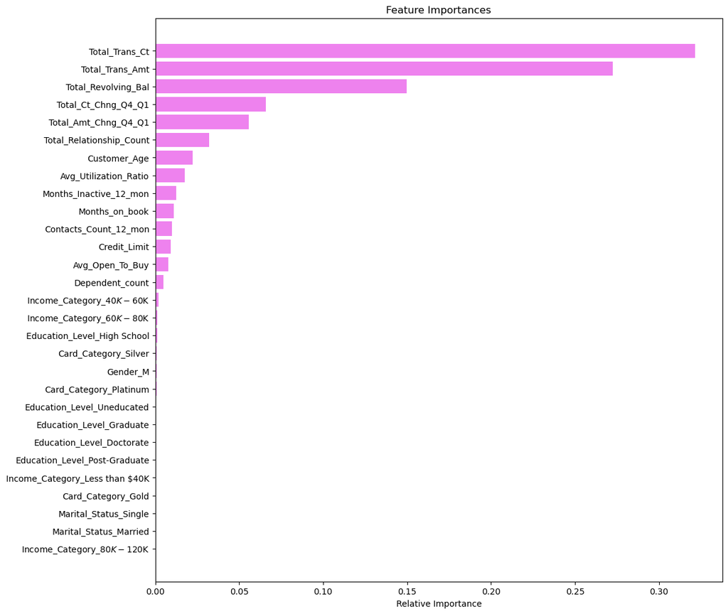

```python
feature_names = X_train.columns
importances = gbm_under_tuned.feature_importances_
indices = np.argsort(importances)

plt.figure(figsize=(12, 12))
plt.title("Feature Importances")
plt.barh(range(len(indices)), importances[indices], color="violet", align="center")
plt.yticks(range(len(indices)), [feature_names[i] for i in indices])
plt.xlabel("Relative Importance")
plt.show()
```

#### Observations

- The selected model had a very good recall on the test set: 0.982
- The most important features were total transaction count and amount, total revolving balance, change in Q4 transactions and amount over Q1, total relationship count.

# Business Insights and Conclusions

#### Insights

- Total transaction amount has a right skewed distibution. The mean total transaction amount was around \$4k however their were many outliers >\$7K which signals heavy spenders and credit card users. Churned customers had a lower total transaction amount.
- Although the top Education_Level is Graduate, most customers have undergraduate or lesser education. Customers with post-graduate or doctorate education levels curiously have a higher chance of attrition than others.
- Most customers make less than \$40K. Customers with either very high incomes or very low incomes have a higher chance of attrition than others.
- The distribution of Total_Ct_Chng_Q4_Q1 is right-skewed with outliers at both ends. Churned customers had a lower total change in transaction count in Q4 over Q1. This indicates that the churned customers did not use this bank's credit card as much for end-of-year holiday shopping as existing customers.
- Equal no. of customers were retained or churned among those that were fully active last year. Customers on either extremes of inactivity i.e. 1-2 months or 5-6 months are less likely to churn. Customers with 3-4 months of inactivity are likely to churn.
- Avg_open_to_buy and credit_limit have a perfect correlation which makes sense as they go hand in hand. More the credit limit, more room their is for purchases on a credit card.
- Total_Trans_Ct is highly correlated with Total_Trans_Amt which makes sense since both are related to the transactions of the credit card holder.
- Months_on_book is correlated with Customer_Age which makes sense since older customers would have more time on the bank's books.
- Avg_Utilization_Ratio has a correlation with Total_Revolving_Bal which makes sense since high utilization could indicate higher revolving balance.
- Avg_open_to_buy and avg_utilization_ratio have a moderate negative correlation which makes sense as you use your credit card more, there is less room to spend.
- Credit limit and utilization ratio have a moderate negative correlation which makes sense because if your income increases, increasing your credit limit but your expenses remains fairly the same, the utilization ratio will decrease.
- The selected model - Gradient Boost with undersampled data had a very good recall on the test set: 0.982
- The 5 most important features were total transaction count and amount, total revolving balance, change in Q4 transactions and amount over Q1.

#### Conclusions

- Our selected ML model with Gradient Boosting trained on undersampled data, can help the bank proactively predict customer churn, monitor key churn reasons and take steps accordingly to better retain customers.
- Let's take a closer look at the top factors that indicate churn:
1. Total transaction count and amount - Unsurprisingly, the more customers use their credit cards, both no. of times and for higher dollar amounts, more likely are they retained. The bank should therefore offer targeted cashbacks and promotions on frequently used merchant services that incentivizes customers to use their credit cards more.
2. Total revolving balance - Churned customers on average had a much lower, near-0 revolving balance. These customers may have found better credit card offers elsewhere and therefore closed out the card with this bank. The bank should conduct win/loss interviews and surveys to look into the churn reason and take appropriate steps to nurture them back as a customer.
3. Change in Q4 transactions and amount over Q1 - Churned cusotmers spent much less and used their cards much less in Q4 over Q1, compared to retained customers. The bank should offer cashbacks and promotions to at-risk customers specifically during the holiday period so this bank's card becomes the preferred choice of card for shopping.
4. Total relationship count - More products used with the bank meant more retention. The bank should investigate what an ideal customer product usage and upsell journey looks like and deploy that for nurturing customers with 1 or 2 products.
- A large part of the customer base is young and female. The bank should look at offering discounts and cashbacks tied to merchant serives and products that appeal to the young female demographic.
- The bank should look at improving the value perception and realization of the Platinum tier card as this saw higher churn than other card tiers. This could include branding and upsell marketing campaigns.
- More contact with the bank meant more churn risk. This could mean dissatisfaction with the bank's services and should be investigated.